# Risk Factor Analysis

## Outcome Variable

**Outcome Variable:** ever_co

## Predictor Variables

**Intervention Variable:** parity

**Adjustment Set:**

- arm
- W_mage
- meducyrs
- feducyrs
- hhwealth_quart
- W_mhtcm
- vagbrth
- W_nrooms
- impsan
- delta_W_mage
- delta_meducyrs
- delta_feducyrs
- delta_hhwealth_quart
- delta_W_mhtcm
- delta_vagbrth
- delta_W_nrooms
- delta_impsan

## Stratifying Variables

The analysis was stratified on these variable(s):

- agecat
- studyid
- country

## Data Summary

| agecat | studyid | country | parity | ever_co | n_cell | n |
| --- | --- | --- | --- | --- | --- | --- |
| 0-24 months | ki1000304b-SAS-CompFeed | INDIA | 1 | 0 | 359 | 1513 |
| 0-24 months | ki1000304b-SAS-CompFeed | INDIA | 1 | 1 | 89 | 1513 |
| 0-24 months | ki1000304b-SAS-CompFeed | INDIA | 2 | 0 | 285 | 1513 |
| 0-24 months | ki1000304b-SAS-CompFeed | INDIA | 2 | 1 | 69 | 1513 |
| 0-24 months | ki1000304b-SAS-CompFeed | INDIA | 3+ | 0 | 518 | 1513 |
| 0-24 months | ki1000304b-SAS-CompFeed | INDIA | 3+ | 1 | 193 | 1513 |
| 0-24 months | ki1000304b-SAS-FoodSuppl | INDIA | 1 | 0 | 57 | 397 |
| 0-24 months | ki1000304b-SAS-FoodSuppl | INDIA | 1 | 1 | 20 | 397 |
| 0-24 months | ki1000304b-SAS-FoodSuppl | INDIA | 2 | 0 | 55 | 397 |
| 0-24 months | ki1000304b-SAS-FoodSuppl | INDIA | 2 | 1 | 37 | 397 |
| 0-24 months | ki1000304b-SAS-FoodSuppl | INDIA | 3+ | 0 | 134 | 397 |
| 0-24 months | ki1000304b-SAS-FoodSuppl | INDIA | 3+ | 1 | 94 | 397 |
| 0-24 months | ki1017093b-PROVIDE | BANGLADESH | 1 | 0 | 232 | 700 |
| 0-24 months | ki1017093b-PROVIDE | BANGLADESH | 1 | 1 | 39 | 700 |
| 0-24 months | ki1017093b-PROVIDE | BANGLADESH | 2 | 0 | 217 | 700 |
| 0-24 months | ki1017093b-PROVIDE | BANGLADESH | 2 | 1 | 27 | 700 |
| 0-24 months | ki1017093b-PROVIDE | BANGLADESH | 3+ | 0 | 161 | 700 |
| 0-24 months | ki1017093b-PROVIDE | BANGLADESH | 3+ | 1 | 24 | 700 |
| 0-24 months | ki1066203-TanzaniaChild2 | TANZANIA, UNITED REPUBLIC OF | 1 | 0 | 783 | 2357 |
| 0-24 months | ki1066203-TanzaniaChild2 | TANZANIA, UNITED REPUBLIC OF | 1 | 1 | 38 | 2357 |
| 0-24 months | ki1066203-TanzaniaChild2 | TANZANIA, UNITED REPUBLIC OF | 2 | 0 | 732 | 2357 |
| 0-24 months | ki1066203-TanzaniaChild2 | TANZANIA, UNITED REPUBLIC OF | 2 | 1 | 39 | 2357 |
| 0-24 months | ki1066203-TanzaniaChild2 | TANZANIA, UNITED REPUBLIC OF | 3+ | 0 | 724 | 2357 |
| 0-24 months | ki1066203-TanzaniaChild2 | TANZANIA, UNITED REPUBLIC OF | 3+ | 1 | 41 | 2357 |
| 0-24 months | ki1101329-Keneba | GAMBIA | 1 | 0 | 212 | 1988 |
| 0-24 months | ki1101329-Keneba | GAMBIA | 1 | 1 | 28 | 1988 |
| 0-24 months | ki1101329-Keneba | GAMBIA | 2 | 0 | 193 | 1988 |
| 0-24 months | ki1101329-Keneba | GAMBIA | 2 | 1 | 21 | 1988 |
| 0-24 months | ki1101329-Keneba | GAMBIA | 3+ | 0 | 1255 | 1988 |
| 0-24 months | ki1101329-Keneba | GAMBIA | 3+ | 1 | 279 | 1988 |

[output cut: 168 more lines]

The following strata were considered:

- agecat: 0-24 months, studyid: ki1000304b-SAS-CompFeed, country: INDIA
- agecat: 0-24 months, studyid: ki1000304b-SAS-FoodSuppl, country: INDIA
- agecat: 0-24 months, studyid: ki1017093b-PROVIDE, country: BANGLADESH
- agecat: 0-24 months, studyid: ki1066203-TanzaniaChild2, country: TANZANIA, UNITED REPUBLIC OF
- agecat: 0-24 months, studyid: ki1101329-Keneba, country: GAMBIA
- agecat: 0-24 months, studyid: ki1113344-GMS-Nepal, country: NEPAL
- agecat: 0-24 months, studyid: ki1126311-ZVITAMBO, country: ZIMBABWE
- agecat: 0-24 months, studyid: ki1135781-COHORTS, country: GUATEMALA
- agecat: 0-24 months, studyid: ki1135781-COHORTS, country: INDIA
- agecat: 0-24 months, studyid: ki1135781-COHORTS, country: PHILIPPINES
- agecat: 0-24 months, studyid: kiGH5241-JiVitA-3, country: BANGLADESH
- agecat: 0-6 months, studyid: ki1000304b-SAS-CompFeed, country: INDIA
- agecat: 0-6 months, studyid: ki1000304b-SAS-FoodSuppl, country: INDIA
- agecat: 0-6 months, studyid: ki1017093b-PROVIDE, country: BANGLADESH
- agecat: 0-6 months, studyid: ki1066203-TanzaniaChild2, country: TANZANIA, UNITED REPUBLIC OF
- agecat: 0-6 months, studyid: ki1101329-Keneba, country: GAMBIA
- agecat: 0-6 months, studyid: ki1113344-GMS-Nepal, country: NEPAL
- agecat: 0-6 months, studyid: ki1126311-ZVITAMBO, country: ZIMBABWE
- agecat: 0-6 months, studyid: ki1135781-COHORTS, country: GUATEMALA
- agecat: 0-6 months, studyid: ki1135781-COHORTS, country: INDIA
- agecat: 0-6 months, studyid: ki1135781-COHORTS, country: PHILIPPINES
- agecat: 0-6 months, studyid: kiGH5241-JiVitA-3, country: BANGLADESH
- agecat: 6-24 months, studyid: ki1000304b-SAS-CompFeed, country: INDIA
- agecat: 6-24 months, studyid: ki1000304b-SAS-FoodSuppl, country: INDIA
- agecat: 6-24 months, studyid: ki1017093b-PROVIDE, country: BANGLADESH
- agecat: 6-24 months, studyid: ki1066203-TanzaniaChild2, country: TANZANIA, UNITED REPUBLIC OF
- agecat: 6-24 months, studyid: ki1101329-Keneba, country: GAMBIA
- agecat: 6-24 months, studyid: ki1113344-GMS-Nepal, country: NEPAL
- agecat: 6-24 months, studyid: ki1126311-ZVITAMBO, country: ZIMBABWE
- agecat: 6-24 months, studyid: ki1135781-COHORTS, country: GUATEMALA
- agecat: 6-24 months, studyid: ki1135781-COHORTS, country: INDIA
- agecat: 6-24 months, studyid: ki1135781-COHORTS, country: PHILIPPINES
- agecat: 6-24 months, studyid: kiGH5241-JiVitA-3, country: BANGLADESH

### Dropped Strata

Some strata were dropped due to rare outcomes:

- agecat: 0-6 months, studyid: ki1101329-Keneba, country: GAMBIA
- agecat: 0-6 months, studyid: ki1135781-COHORTS, country: GUATEMALA

## Methods Detail

We’re interested in the causal parameters $E[Y_a]$ for all values of $a \in \mathcal{A}$. These parameters represent the mean outcome if, possibly contrary to fact, we intervened to set all units to have $A=a$. Under the randomization and positivity assumptions, these are identified by the statistical parameters $\psi_a=E_W[E_{Y|A,W}(Y|A=a,W)]$. In addition, we’re interested in the mean of $Y$, $E[Y]$ under no intervention (the observed mean). We will estimate these parameters by using SuperLearner to fit the relevant likelihood factors – $E_{Y|A,W}(Y|A=a,W)$ and $p(A=a|W)$, and then updating our likelihood fit using a joint TMLE.

For unadjusted analyses ($W=\{\}$), initial likelihoods were estimated using Lrnr_glm to estimate the simple $E(Y|A)$ and Lrnr_mean to estimate $p(A)$. For adjusted analyses, a small library containing Lrnr_glmnet, Lrnr_xgboost, and Lrnr_mean was used.

Having estimated these parameters, we will then use the delta method to estimate relative risks and attributable risks relative to a prespecified baseline level of $A$.

# Results Detail

## Results Plots

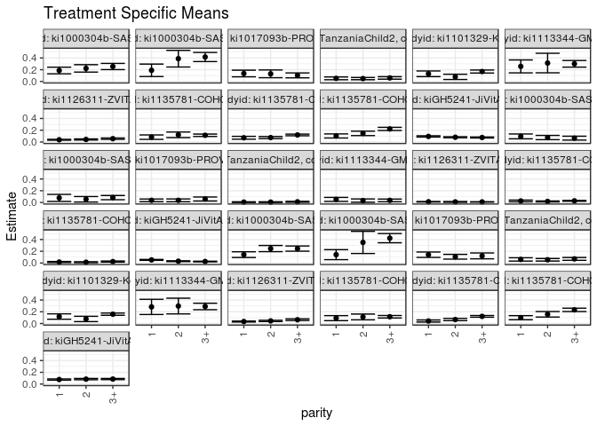

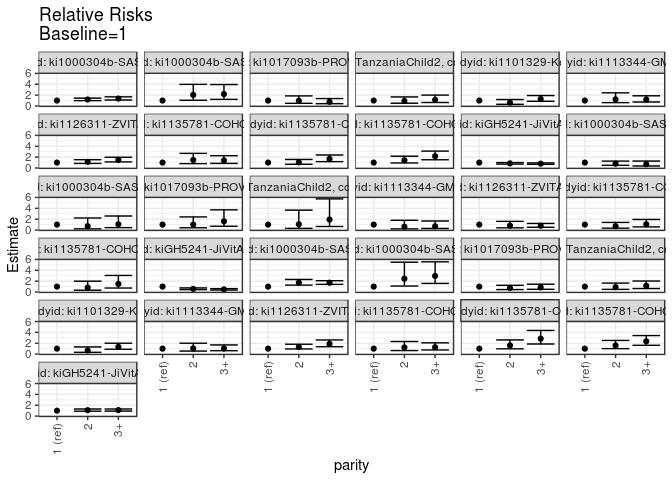

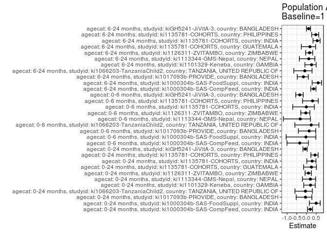

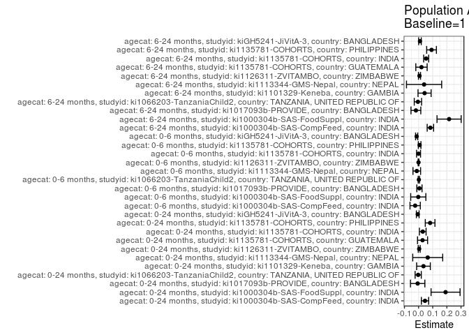

## Results Table

### Parameter: TSM

| agecat | studyid | country | intervention_level | baseline_level | estimate | ci_lower | ci_upper |
| --- | --- | --- | --- | --- | --- | --- | --- |
| 0-24 months | ki1000304b-SAS-CompFeed | INDIA | 1 | NA | 0.1865892 | 0.1301678 | 0.2430107 |
| 0-24 months | ki1000304b-SAS-CompFeed | INDIA | 2 | NA | 0.2221185 | 0.1587888 | 0.2854481 |
| 0-24 months | ki1000304b-SAS-CompFeed | INDIA | 3+ | NA | 0.2542407 | 0.2012202 | 0.3072612 |
| 0-24 months | ki1000304b-SAS-FoodSuppl | INDIA | 1 | NA | 0.1895945 | 0.0835938 | 0.2955952 |
| 0-24 months | ki1000304b-SAS-FoodSuppl | INDIA | 2 | NA | 0.3875451 | 0.2460019 | 0.5290884 |
| 0-24 months | ki1000304b-SAS-FoodSuppl | INDIA | 3+ | NA | 0.4159472 | 0.3384713 | 0.4934231 |
| 0-24 months | ki1017093b-PROVIDE | BANGLADESH | 1 | NA | 0.1350939 | 0.0782747 | 0.1919130 |
| 0-24 months | ki1017093b-PROVIDE | BANGLADESH | 2 | NA | 0.1296047 | 0.0636024 | 0.1956069 |
| 0-24 months | ki1017093b-PROVIDE | BANGLADESH | 3+ | NA | 0.1031401 | 0.0614446 | 0.1448357 |
| 0-24 months | ki1066203-TanzaniaChild2 | TANZANIA, UNITED REPUBLIC OF | 1 | NA | 0.0527761 | 0.0291462 | 0.0764059 |
| 0-24 months | ki1066203-TanzaniaChild2 | TANZANIA, UNITED REPUBLIC OF | 2 | NA | 0.0486686 | 0.0298932 | 0.0674440 |
| 0-24 months | ki1066203-TanzaniaChild2 | TANZANIA, UNITED REPUBLIC OF | 3+ | NA | 0.0598842 | 0.0388676 | 0.0809008 |
| 0-24 months | ki1101329-Keneba | GAMBIA | 1 | NA | 0.1303789 | 0.0822027 | 0.1785550 |
| 0-24 months | ki1101329-Keneba | GAMBIA | 2 | NA | 0.0780461 | 0.0331562 | 0.1229359 |
| 0-24 months | ki1101329-Keneba | GAMBIA | 3+ | NA | 0.1684536 | 0.1428347 | 0.1940726 |
| 0-24 months | ki1113344-GMS-Nepal | NEPAL | 1 | NA | 0.2559261 | 0.1458085 | 0.3660437 |
| 0-24 months | ki1113344-GMS-Nepal | NEPAL | 2 | NA | 0.3130965 | 0.1468751 | 0.4793179 |
| 0-24 months | ki1113344-GMS-Nepal | NEPAL | 3+ | NA | 0.3001586 | 0.2438439 | 0.3564732 |
| 0-24 months | ki1126311-ZVITAMBO | ZIMBABWE | 1 | NA | 0.0374396 | 0.0300908 | 0.0447884 |
| 0-24 months | ki1126311-ZVITAMBO | ZIMBABWE | 2 | NA | 0.0425250 | 0.0330731 | 0.0519768 |
| 0-24 months | ki1126311-ZVITAMBO | ZIMBABWE | 3+ | NA | 0.0559151 | 0.0443453 | 0.0674849 |
| 0-24 months | ki1135781-COHORTS | GUATEMALA | 1 | NA | 0.0823005 | 0.0445635 | 0.1200375 |
| 0-24 months | ki1135781-COHORTS | GUATEMALA | 2 | NA | 0.1213721 | 0.0738630 | 0.1688812 |
| 0-24 months | ki1135781-COHORTS | GUATEMALA | 3+ | NA | 0.1140179 | 0.0937461 | 0.1342898 |
| 0-24 months | ki1135781-COHORTS | INDIA | 1 | NA | 0.0713354 | 0.0472428 | 0.0954280 |
| 0-24 months | ki1135781-COHORTS | INDIA | 2 | NA | 0.0741873 | 0.0564457 | 0.0919289 |
| 0-24 months | ki1135781-COHORTS | INDIA | 3+ | NA | 0.1194935 | 0.1054895 | 0.1334975 |
| 0-24 months | ki1135781-COHORTS | PHILIPPINES | 1 | NA | 0.1023704 | 0.0676788 | 0.1370620 |
| 0-24 months | ki1135781-COHORTS | PHILIPPINES | 2 | NA | 0.1456796 | 0.1083632 | 0.1829960 |
| 0-24 months | ki1135781-COHORTS | PHILIPPINES | 3+ | NA | 0.2221054 | 0.1950151 | 0.2491958 |

[output cut: 63 more lines]

### Parameter: E(Y)

| agecat | studyid | country | intervention_level | baseline_level | estimate | ci_lower | ci_upper |
| --- | --- | --- | --- | --- | --- | --- | --- |
| 0-24 months | ki1000304b-SAS-CompFeed | INDIA | NA | NA | 0.2319894 | 0.1917264 | 0.2722524 |
| 0-24 months | ki1000304b-SAS-FoodSuppl | INDIA | NA | NA | 0.3803526 | 0.3325374 | 0.4281678 |
| 0-24 months | ki1017093b-PROVIDE | BANGLADESH | NA | NA | 0.1285714 | 0.1037574 | 0.1533855 |
| 0-24 months | ki1066203-TanzaniaChild2 | TANZANIA, UNITED REPUBLIC OF | NA | NA | 0.0500636 | 0.0412578 | 0.0588694 |
| 0-24 months | ki1101329-Keneba | GAMBIA | NA | NA | 0.1649899 | 0.1486698 | 0.1813101 |
| 0-24 months | ki1113344-GMS-Nepal | NEPAL | NA | NA | 0.3205980 | 0.2832855 | 0.3579105 |
| 0-24 months | ki1126311-ZVITAMBO | ZIMBABWE | NA | NA | 0.0417683 | 0.0384465 | 0.0450902 |
| 0-24 months | ki1135781-COHORTS | GUATEMALA | NA | NA | 0.1103654 | 0.0935883 | 0.1271425 |
| 0-24 months | ki1135781-COHORTS | INDIA | NA | NA | 0.1008003 | 0.0921209 | 0.1094798 |
| 0-24 months | ki1135781-COHORTS | PHILIPPINES | NA | NA | 0.1839080 | 0.1701456 | 0.1976705 |
| 0-24 months | kiGH5241-JiVitA-3 | BANGLADESH | NA | NA | 0.0885064 | 0.0846302 | 0.0923827 |
| 0-6 months | ki1000304b-SAS-CompFeed | INDIA | NA | NA | 0.0704787 | 0.0478990 | 0.0930584 |
| 0-6 months | ki1000304b-SAS-FoodSuppl | INDIA | NA | NA | 0.0757576 | 0.0496627 | 0.1018525 |
| 0-6 months | ki1017093b-PROVIDE | BANGLADESH | NA | NA | 0.0428571 | 0.0278427 | 0.0578716 |
| 0-6 months | ki1066203-TanzaniaChild2 | TANZANIA, UNITED REPUBLIC OF | NA | NA | 0.0080611 | 0.0044503 | 0.0116719 |
| 0-6 months | ki1113344-GMS-Nepal | NEPAL | NA | NA | 0.0398671 | 0.0242254 | 0.0555088 |
| 0-6 months | ki1126311-ZVITAMBO | ZIMBABWE | NA | NA | 0.0120673 | 0.0102481 | 0.0138865 |
| 0-6 months | ki1135781-COHORTS | INDIA | NA | NA | 0.0263336 | 0.0216247 | 0.0310425 |
| 0-6 months | ki1135781-COHORTS | PHILIPPINES | NA | NA | 0.0236531 | 0.0182537 | 0.0290525 |
| 0-6 months | kiGH5241-JiVitA-3 | BANGLADESH | NA | NA | 0.0393357 | 0.0368510 | 0.0418204 |
| 6-24 months | ki1000304b-SAS-CompFeed | INDIA | NA | NA | 0.2260619 | 0.1909133 | 0.2612105 |
| 6-24 months | ki1000304b-SAS-FoodSuppl | INDIA | NA | NA | 0.3578680 | 0.3104738 | 0.4052622 |
| 6-24 months | ki1017093b-PROVIDE | BANGLADESH | NA | NA | 0.1221498 | 0.0962275 | 0.1480722 |
| 6-24 months | ki1066203-TanzaniaChild2 | TANZANIA, UNITED REPUBLIC OF | NA | NA | 0.0563948 | 0.0462467 | 0.0665428 |
| 6-24 months | ki1101329-Keneba | GAMBIA | NA | NA | 0.1612064 | 0.1447669 | 0.1776460 |
| 6-24 months | ki1113344-GMS-Nepal | NEPAL | NA | NA | 0.3220339 | 0.2842988 | 0.3597690 |
| 6-24 months | ki1126311-ZVITAMBO | ZIMBABWE | NA | NA | 0.0406846 | 0.0369398 | 0.0444295 |
| 6-24 months | ki1135781-COHORTS | GUATEMALA | NA | NA | 0.1123039 | 0.0945135 | 0.1300943 |
| 6-24 months | ki1135781-COHORTS | INDIA | NA | NA | 0.0965883 | 0.0877969 | 0.1053797 |
| 6-24 months | ki1135781-COHORTS | PHILIPPINES | NA | NA | 0.1908832 | 0.1763448 | 0.2054216 |
| 6-24 months | kiGH5241-JiVitA-3 | BANGLADESH | NA | NA | 0.0867929 | 0.0821342 | 0.0914516 |

### Parameter: RR

| agecat | studyid | country | intervention_level | baseline_level | estimate | ci_lower | ci_upper |
| --- | --- | --- | --- | --- | --- | --- | --- |
| 0-24 months | ki1000304b-SAS-CompFeed | INDIA | 1 | 1 | 1.0000000 | 1.0000000 | 1.0000000 |
| 0-24 months | ki1000304b-SAS-CompFeed | INDIA | 2 | 1 | 1.1904142 | 0.9814029 | 1.4439390 |
| 0-24 months | ki1000304b-SAS-CompFeed | INDIA | 3+ | 1 | 1.3625690 | 1.1014228 | 1.6856326 |
| 0-24 months | ki1000304b-SAS-FoodSuppl | INDIA | 1 | 1 | 1.0000000 | 1.0000000 | 1.0000000 |
| 0-24 months | ki1000304b-SAS-FoodSuppl | INDIA | 2 | 1 | 2.0440742 | 1.0501779 | 3.9786015 |
| 0-24 months | ki1000304b-SAS-FoodSuppl | INDIA | 3+ | 1 | 2.1938783 | 1.2185706 | 3.9497932 |
| 0-24 months | ki1017093b-PROVIDE | BANGLADESH | 1 | 1 | 1.0000000 | 1.0000000 | 1.0000000 |
| 0-24 months | ki1017093b-PROVIDE | BANGLADESH | 2 | 1 | 0.9593675 | 0.4961982 | 1.8548758 |
| 0-24 months | ki1017093b-PROVIDE | BANGLADESH | 3+ | 1 | 0.7634700 | 0.4263247 | 1.3672360 |
| 0-24 months | ki1066203-TanzaniaChild2 | TANZANIA, UNITED REPUBLIC OF | 1 | 1 | 1.0000000 | 1.0000000 | 1.0000000 |
| 0-24 months | ki1066203-TanzaniaChild2 | TANZANIA, UNITED REPUBLIC OF | 2 | 1 | 0.9221717 | 0.5106211 | 1.6654239 |
| 0-24 months | ki1066203-TanzaniaChild2 | TANZANIA, UNITED REPUBLIC OF | 3+ | 1 | 1.1346857 | 0.6422987 | 2.0045372 |
| 0-24 months | ki1101329-Keneba | GAMBIA | 1 | 1 | 1.0000000 | 1.0000000 | 1.0000000 |
| 0-24 months | ki1101329-Keneba | GAMBIA | 2 | 1 | 0.5986097 | 0.3021362 | 1.1860002 |
| 0-24 months | ki1101329-Keneba | GAMBIA | 3+ | 1 | 1.2920315 | 0.8674334 | 1.9244650 |
| 0-24 months | ki1113344-GMS-Nepal | NEPAL | 1 | 1 | 1.0000000 | 1.0000000 | 1.0000000 |
| 0-24 months | ki1113344-GMS-Nepal | NEPAL | 2 | 1 | 1.2233863 | 0.6178281 | 2.4224765 |
| 0-24 months | ki1113344-GMS-Nepal | NEPAL | 3+ | 1 | 1.1728329 | 0.7331990 | 1.8760758 |
| 0-24 months | ki1126311-ZVITAMBO | ZIMBABWE | 1 | 1 | 1.0000000 | 1.0000000 | 1.0000000 |
| 0-24 months | ki1126311-ZVITAMBO | ZIMBABWE | 2 | 1 | 1.1358288 | 0.8443938 | 1.5278500 |
| 0-24 months | ki1126311-ZVITAMBO | ZIMBABWE | 3+ | 1 | 1.4934748 | 1.1228423 | 1.9864472 |
| 0-24 months | ki1135781-COHORTS | GUATEMALA | 1 | 1 | 1.0000000 | 1.0000000 | 1.0000000 |
| 0-24 months | ki1135781-COHORTS | GUATEMALA | 2 | 1 | 1.4747426 | 0.8071035 | 2.6946552 |
| 0-24 months | ki1135781-COHORTS | GUATEMALA | 3+ | 1 | 1.3853852 | 0.8471695 | 2.2655350 |
| 0-24 months | ki1135781-COHORTS | INDIA | 1 | 1 | 1.0000000 | 1.0000000 | 1.0000000 |
| 0-24 months | ki1135781-COHORTS | INDIA | 2 | 1 | 1.0399787 | 0.6877990 | 1.5724879 |
| 0-24 months | ki1135781-COHORTS | INDIA | 3+ | 1 | 1.6750946 | 1.1720312 | 2.3940848 |
| 0-24 months | ki1135781-COHORTS | PHILIPPINES | 1 | 1 | 1.0000000 | 1.0000000 | 1.0000000 |
| 0-24 months | ki1135781-COHORTS | PHILIPPINES | 2 | 1 | 1.4230634 | 0.9308581 | 2.1755298 |
| 0-24 months | ki1135781-COHORTS | PHILIPPINES | 3+ | 1 | 2.1696253 | 1.5132125 | 3.1107820 |

[output cut: 63 more lines]

### Parameter: PAR

| agecat | studyid | country | intervention_level | baseline_level | estimate | ci_lower | ci_upper |
| --- | --- | --- | --- | --- | --- | --- | --- |
| 0-24 months | ki1000304b-SAS-CompFeed | INDIA | 1 | NA | 0.0454002 | 0.0197287 | 0.0710717 |
| 0-24 months | ki1000304b-SAS-FoodSuppl | INDIA | 1 | NA | 0.1907582 | 0.0882541 | 0.2932622 |
| 0-24 months | ki1017093b-PROVIDE | BANGLADESH | 1 | NA | -0.0065224 | -0.0573556 | 0.0443107 |
| 0-24 months | ki1066203-TanzaniaChild2 | TANZANIA, UNITED REPUBLIC OF | 1 | NA | -0.0027124 | -0.0245122 | 0.0190874 |
| 0-24 months | ki1101329-Keneba | GAMBIA | 1 | NA | 0.0346111 | -0.0137393 | 0.0829614 |
| 0-24 months | ki1113344-GMS-Nepal | NEPAL | 1 | NA | 0.0646719 | -0.0413143 | 0.1706580 |
| 0-24 months | ki1126311-ZVITAMBO | ZIMBABWE | 1 | NA | 0.0043287 | -0.0024192 | 0.0110767 |
| 0-24 months | ki1135781-COHORTS | GUATEMALA | 1 | NA | 0.0280649 | -0.0075667 | 0.0636964 |
| 0-24 months | ki1135781-COHORTS | INDIA | 1 | NA | 0.0294650 | 0.0059370 | 0.0529930 |
| 0-24 months | ki1135781-COHORTS | PHILIPPINES | 1 | NA | 0.0815376 | 0.0473749 | 0.1157004 |
| 0-24 months | kiGH5241-JiVitA-3 | BANGLADESH | 1 | NA | -0.0059275 | -0.0156275 | 0.0037724 |
| 0-6 months | ki1000304b-SAS-CompFeed | INDIA | 1 | NA | -0.0242966 | -0.0606613 | 0.0120681 |
| 0-6 months | ki1000304b-SAS-FoodSuppl | INDIA | 1 | NA | -0.0021645 | -0.0558026 | 0.0514736 |
| 0-6 months | ki1017093b-PROVIDE | BANGLADESH | 1 | NA | 0.0059568 | -0.0124634 | 0.0243770 |
| 0-6 months | ki1066203-TanzaniaChild2 | TANZANIA, UNITED REPUBLIC OF | 1 | NA | 0.0019710 | -0.0026802 | 0.0066221 |
| 0-6 months | ki1113344-GMS-Nepal | NEPAL | 1 | NA | -0.0127645 | -0.0397689 | 0.0142400 |
| 0-6 months | ki1126311-ZVITAMBO | ZIMBABWE | 1 | NA | -0.0004064 | -0.0032148 | 0.0024020 |
| 0-6 months | ki1135781-COHORTS | INDIA | 1 | NA | -0.0001686 | -0.0141823 | 0.0138451 |
| 0-6 months | ki1135781-COHORTS | PHILIPPINES | 1 | NA | 0.0074188 | -0.0018661 | 0.0167038 |
| 0-6 months | kiGH5241-JiVitA-3 | BANGLADESH | 1 | NA | -0.0136089 | -0.0212167 | -0.0060011 |
| 6-24 months | ki1000304b-SAS-CompFeed | INDIA | 1 | NA | 0.0835388 | 0.0607939 | 0.1062837 |
| 6-24 months | ki1000304b-SAS-FoodSuppl | INDIA | 1 | NA | 0.2157465 | 0.1303118 | 0.3011812 |
| 6-24 months | ki1017093b-PROVIDE | BANGLADESH | 1 | NA | -0.0190322 | -0.0536831 | 0.0156188 |
| 6-24 months | ki1066203-TanzaniaChild2 | TANZANIA, UNITED REPUBLIC OF | 1 | NA | -0.0047143 | -0.0305537 | 0.0211252 |
| 6-24 months | ki1101329-Keneba | GAMBIA | 1 | NA | 0.0423615 | -0.0038988 | 0.0886219 |
| 6-24 months | ki1113344-GMS-Nepal | NEPAL | 1 | NA | 0.0389105 | -0.0854542 | 0.1632752 |
| 6-24 months | ki1126311-ZVITAMBO | ZIMBABWE | 1 | NA | 0.0064667 | -0.0008819 | 0.0138152 |
| 6-24 months | ki1135781-COHORTS | GUATEMALA | 1 | NA | 0.0204690 | -0.0196058 | 0.0605437 |
| 6-24 months | ki1135781-COHORTS | INDIA | 1 | NA | 0.0536743 | 0.0359392 | 0.0714094 |
| 6-24 months | ki1135781-COHORTS | PHILIPPINES | 1 | NA | 0.0917092 | 0.0573332 | 0.1260851 |
| 6-24 months | kiGH5241-JiVitA-3 | BANGLADESH | 1 | NA | 0.0097462 | 0.0005669 | 0.0189255 |

### Parameter: PAF

| agecat | studyid | country | intervention_level | baseline_level | estimate | ci_lower | ci_upper |
| --- | --- | --- | --- | --- | --- | --- | --- |
| 0-24 months | ki1000304b-SAS-CompFeed | INDIA | 1 | NA | 0.1956994 | 0.0555862 | 0.3150254 |
| 0-24 months | ki1000304b-SAS-FoodSuppl | INDIA | 1 | NA | 0.5015298 | 0.1486113 | 0.7081562 |
| 0-24 months | ki1017093b-PROVIDE | BANGLADESH | 1 | NA | -0.0507300 | -0.5307763 | 0.2787754 |
| 0-24 months | ki1066203-TanzaniaChild2 | TANZANIA, UNITED REPUBLIC OF | 1 | NA | -0.0541792 | -0.5932747 | 0.3025096 |
| 0-24 months | ki1101329-Keneba | GAMBIA | 1 | NA | 0.2097768 | -0.1406566 | 0.4525497 |
| 0-24 months | ki1113344-GMS-Nepal | NEPAL | 1 | NA | 0.2017227 | -0.2068519 | 0.4719761 |
| 0-24 months | ki1126311-ZVITAMBO | ZIMBABWE | 1 | NA | 0.1036369 | -0.0730814 | 0.2512527 |
| 0-24 months | ki1135781-COHORTS | GUATEMALA | 1 | NA | 0.2542904 | -0.1469608 | 0.5151684 |
| 0-24 months | ki1135781-COHORTS | INDIA | 1 | NA | 0.2923102 | 0.0180708 | 0.4899582 |
| 0-24 months | ki1135781-COHORTS | PHILIPPINES | 1 | NA | 0.4433609 | 0.2262642 | 0.5995440 |
| 0-24 months | kiGH5241-JiVitA-3 | BANGLADESH | 1 | NA | -0.0669730 | -0.1823140 | 0.0371158 |
| 0-6 months | ki1000304b-SAS-CompFeed | INDIA | 1 | NA | -0.3447369 | -1.0051084 | 0.0981448 |
| 0-6 months | ki1000304b-SAS-FoodSuppl | INDIA | 1 | NA | -0.0285714 | -1.0471955 | 0.4832154 |
| 0-6 months | ki1017093b-PROVIDE | BANGLADESH | 1 | NA | 0.1389914 | -0.4142101 | 0.4757951 |
| 0-6 months | ki1066203-TanzaniaChild2 | TANZANIA, UNITED REPUBLIC OF | 1 | NA | 0.2445028 | -0.5993898 | 0.6431289 |
| 0-6 months | ki1113344-GMS-Nepal | NEPAL | 1 | NA | -0.3201754 | -1.1878788 | 0.2034005 |
| 0-6 months | ki1126311-ZVITAMBO | ZIMBABWE | 1 | NA | -0.0336740 | -0.2947061 | 0.1747302 |
| 0-6 months | ki1135781-COHORTS | INDIA | 1 | NA | -0.0064029 | -0.7077370 | 0.4069071 |
| 0-6 months | ki1135781-COHORTS | PHILIPPINES | 1 | NA | 0.3136519 | -0.2032694 | 0.6085052 |
| 0-6 months | kiGH5241-JiVitA-3 | BANGLADESH | 1 | NA | -0.3459681 | -0.5542210 | -0.1656194 |
| 6-24 months | ki1000304b-SAS-CompFeed | INDIA | 1 | NA | 0.3695394 | 0.2204433 | 0.4901198 |
| 6-24 months | ki1000304b-SAS-FoodSuppl | INDIA | 1 | NA | 0.6028661 | 0.2928546 | 0.7769690 |
| 6-24 months | ki1017093b-PROVIDE | BANGLADESH | 1 | NA | -0.1558099 | -0.4748963 | 0.0942437 |
| 6-24 months | ki1066203-TanzaniaChild2 | TANZANIA, UNITED REPUBLIC OF | 1 | NA | -0.0835943 | -0.6535851 | 0.2899207 |
| 6-24 months | ki1101329-Keneba | GAMBIA | 1 | NA | 0.2627782 | -0.0814949 | 0.4974586 |
| 6-24 months | ki1113344-GMS-Nepal | NEPAL | 1 | NA | 0.1208274 | -0.3641303 | 0.4333793 |
| 6-24 months | ki1126311-ZVITAMBO | ZIMBABWE | 1 | NA | 0.1589463 | -0.0416894 | 0.3209383 |
| 6-24 months | ki1135781-COHORTS | GUATEMALA | 1 | NA | 0.1822640 | -0.2641637 | 0.4710399 |
| 6-24 months | ki1135781-COHORTS | INDIA | 1 | NA | 0.5557022 | 0.3381650 | 0.7017376 |
| 6-24 months | ki1135781-COHORTS | PHILIPPINES | 1 | NA | 0.4804465 | 0.2694247 | 0.6305161 |
| 6-24 months | kiGH5241-JiVitA-3 | BANGLADESH | 1 | NA | 0.1122928 | 0.0000888 | 0.2119060 |